# Predicting house prices using k-nearest neighbors regression

In this notebook, you will implement k-nearest neighbors regression. You will:

- Find the k-nearest neighbors of a given query input
- Predict the output for the query input using the k-nearest neighbors
- Choose the best value of k using a validation set

# Import packages

```python
import pandas as pd
import numpy as np
```

# Load in house sales data

For this notebook, we use a subset of the King County housing dataset created by randomly selecting 40% of the houses in the full dataset.

```python
dtype_dict = {'bathrooms':float, 'waterfront':int, 'sqft_above':int,
              'sqft_living15':float, 'grade':int, 'yr_renovated':int,
              'price':float, 'bedrooms':float, 'zipcode':str, 'long':float,
              'sqft_lot15':float, 'sqft_living':float, 'floors':float,
              'condition':int, 'lat':float, 'date':str, 'sqft_basement':int,
              'yr_built':int, 'id':str, 'sqft_lot':int, 'view':int}
sales = pd.read_csv('kc_house_data_small.csv', dtype = dtype_dict)
```

# Import useful functions from previous notebooks

To efficiently compute pairwise distances among data points, we will convert the SFrame into a 2D Numpy array. First import the numpy library and then copy and paste `get_numpy_data()` from the second notebook of Week 2.

```python
import numpy as np # note this allows us to refer to numpy as np instead
```

```python
def get_numpy_data(data, features, output):
    # add a constant column to a data_Frame
    data['constant'] = 1
    # prepend variable 'constant' to the features list
    if 'constant' not in features:
        features.insert(0, 'constant')
    # select the columns of data_Frame given by the ‘features’ list
    feature_matrix = data[features].values
    #assign the column of data associated with the target to the variable 'output'
    output_array = data[output].values
    return(feature_matrix, output_array)
```

We will also need the `normalize_features()` function from Week 5 that normalizes all feature columns to unit norm. Paste this function below.

```python
def normalize_features(feature_matrix):
    #Compute 2-norms of columns
    norms = np.linalg.norm(feature_matrix, axis=0)
    #Normalize columns and perform element-wise division
    normalized_features = feature_matrix/norms
    return (normalized_features, norms)
```

# Split data into training, test, and validation sets

```python
train = pd.read_csv('kc_house_data_small_train.csv', dtype = dtype_dict)
validation = pd.read_csv('kc_house_data_validation.csv', dtype = dtype_dict)
test = pd.read_csv('kc_house_data_small_test.csv', dtype = dtype_dict)
```

```python
train.head(3)
```

|  | id | date | price | bedrooms | bathrooms | sqft_living | sqft_lot | floors | waterfront | view | ... | sqft_above | sqft_basement | yr_built | yr_renovated | zipcode | lat | long | sqft_living15 | sqft_lot15 | constant |
| --- | --- | --- | --- | --- | --- | --- | --- | --- | --- | --- | --- | --- | --- | --- | --- | --- | --- | --- | --- | --- | --- |
| 0 | 7129300520 | 20141013T000000 | 221900.0 | 3.0 | 1.00 | 1180.0 | 5650 | 1.0 | 0 | 0 | ... | 1180 | 0 | 1955 | 0 | 98178 | 47.5112 | -122.257 | 1340.0 | 5650.0 | 1 |
| 1 | 6414100192 | 20141209T000000 | 538000.0 | 3.0 | 2.25 | 2570.0 | 7242 | 2.0 | 0 | 0 | ... | 2170 | 400 | 1951 | 1991 | 98125 | 47.7210 | -122.319 | 1690.0 | 7639.0 | 1 |
| 2 | 5631500400 | 20150225T000000 | 180000.0 | 2.0 | 1.00 | 770.0 | 10000 | 1.0 | 0 | 0 | ... | 770 | 0 | 1933 | 0 | 98028 | 47.7379 | -122.233 | 2720.0 | 8062.0 | 1 |

3 rows × 22 columns

# Extract features and normalize

Using all of the numerical inputs listed in `feature_list`, transform the training, test, and validation SFrames into Numpy arrays:

```python
feature_list = ['bedrooms',
                'bathrooms',
                'sqft_living',
                'sqft_lot',
                'floors',
                'waterfront',
                'view',
                'condition',
                'grade',
                'sqft_above',
                'sqft_basement',
                'yr_built',
                'yr_renovated',
                'lat',
                'long',
                'sqft_living15',
                'sqft_lot15']
features_train, output_train = get_numpy_data(train, feature_list, 'price')
features_test, output_test = get_numpy_data(test, feature_list, 'price')
features_valid, output_valid = get_numpy_data(validation, feature_list, 'price')
```

In computing distances, it is crucial to normalize features. Otherwise, for example, the `sqft_living` feature (typically on the order of thousands) would exert a much larger influence on distance than the `bedrooms` feature (typically on the order of ones). We divide each column of the training feature matrix by its 2-norm, so that the transformed column has unit norm.

IMPORTANT: Make sure to store the norms of the features in the training set. The features in the test and validation sets must be divided by these same norms, so that the training, test, and validation sets are normalized consistently.

```python
features_train, norms = normalize_features(features_train) # normalize training set features (columns)
features_test = features_test / norms # normalize test set by training set norms
features_valid = features_valid / norms # normalize validation set by training set norms
```

# Compute a single distance

To start, let's just explore computing the "distance" between two given houses. We will take our **query house** to be the first house of the test set and look at the distance between this house and the 10th house of the training set.

```python
query_house = features_test[0]
print(features_test[0])
```

```
[ 0.01345102  0.01551285  0.01807473  0.01759212  0.00160518  0.017059
  0.          0.05102365  0.0116321   0.01564352  0.01362084  0.02481682
  0.01350306  0.          0.01345387 -0.01346922  0.01375926  0.0016225 ]
```

```python
print(features_train[9])
```

```
[ 0.01345102  0.01163464  0.00602491  0.0083488   0.00050756  0.01279425
  0.          0.          0.01938684  0.01390535  0.0096309   0.
  0.01302544  0.          0.01346821 -0.01346251  0.01195898  0.00156612]
```

*QUIZ QUESTION*

What is the Euclidean distance between the query house and the 10th house of the training set?

Note: Do not use the `np.linalg.norm` function; use `np.sqrt`, `np.sum`, and the power operator (`**`) instead. The latter approach is more easily adapted to computing multiple distances at once.

```python
euclidean_distance = np.sqrt(np.sum((features_train[9] - query_house)**2))
print (euclidean_distance)
```

```
0.05972359371398078
```

# Compute multiple distances

Of course, to do nearest neighbor regression, we need to compute the distance between our query house and *all* houses in the training set.

To visualize this nearest-neighbor search, let's first compute the distance from our query house (`features_test[0]`) to the first 10 houses of the training set (`features_train[0:10]`) and then search for the nearest neighbor within this small set of houses. Through restricting ourselves to a small set of houses to begin with, we can visually scan the list of 10 distances to verify that our code for finding the nearest neighbor is working.

Write a loop to compute the Euclidean distance from the query house to each of the first 10 houses in the training set.

```python
dist_dict = {}
for i in range(0,10):
    dist_dict[i] = np.sqrt(np.sum((features_train[i] - query_house)**2))
    print (i, dist_dict[i])
```

```
0 0.06027470916295592
1 0.08546881147643746
2 0.06149946435279315
3 0.05340273979294363
4 0.05844484060170442
5 0.059879215098128345
6 0.05463140496775461
7 0.055431083236146074
8 0.052383627840220305
9 0.05972359371398078
```

*QUIZ QUESTION*

Among the first 10 training houses, which house is the closest to the query house?

```python
print (min(dist_dict.items(), key=lambda x: x[1]))
print (min(dist_dict, key=dist_dict.get)) #return key
```

```
(8, 0.052383627840220305)
8
```

It is computationally inefficient to loop over computing distances to all houses in our training dataset. Fortunately, many of the Numpy functions can be **vectorized**, applying the same operation over multiple values or vectors. We now walk through this process.

Consider the following loop that computes the element-wise difference between the features of the query house (`features_test[0]`) and the first 3 training houses (`features_train[0:3]`):

```python
for i in range(3):
    print (features_train[i]-features_test[0])
    # should print 3 vectors of length 18
```

```
[ 0.00000000e+00 -3.87821276e-03 -1.20498190e-02 -1.05552733e-02
  2.08673616e-04 -8.52950206e-03  0.00000000e+00 -5.10236549e-02
  0.00000000e+00 -3.47633726e-03 -5.50336860e-03 -2.48168183e-02
 -1.63756198e-04  0.00000000e+00 -1.70254220e-05  1.29876855e-05
 -5.14364795e-03  6.69281453e-04]
[ 0.00000000e+00 -3.87821276e-03 -4.51868214e-03 -2.26610387e-03
  7.19763456e-04  0.00000000e+00  0.00000000e+00 -5.10236549e-02
  0.00000000e+00 -3.47633726e-03  1.30705004e-03 -1.45830788e-02
 -1.91048898e-04  6.65082271e-02  4.23090220e-05  6.16364736e-06
 -2.89330197e-03  1.47606982e-03]
[ 0.00000000e+00 -7.75642553e-03 -1.20498190e-02 -1.30002801e-02
  1.60518166e-03 -8.52950206e-03  0.00000000e+00 -5.10236549e-02
  0.00000000e+00 -5.21450589e-03 -8.32384500e-03 -2.48168183e-02
 -3.13866046e-04  0.00000000e+00  4.70885840e-05  1.56292487e-05
  3.72914476e-03  1.64764925e-03]
```

The subtraction operator (`-`) in Numpy is vectorized as follows:

```python
print (features_train[0:3] - features_test[0])
```

```
[[ 0.00000000e+00 -3.87821276e-03 -1.20498190e-02 -1.05552733e-02
   2.08673616e-04 -8.52950206e-03  0.00000000e+00 -5.10236549e-02
   0.00000000e+00 -3.47633726e-03 -5.50336860e-03 -2.48168183e-02
  -1.63756198e-04  0.00000000e+00 -1.70254220e-05  1.29876855e-05
  -5.14364795e-03  6.69281453e-04]
 [ 0.00000000e+00 -3.87821276e-03 -4.51868214e-03 -2.26610387e-03
   7.19763456e-04  0.00000000e+00  0.00000000e+00 -5.10236549e-02
   0.00000000e+00 -3.47633726e-03  1.30705004e-03 -1.45830788e-02
  -1.91048898e-04  6.65082271e-02  4.23090220e-05  6.16364736e-06
  -2.89330197e-03  1.47606982e-03]
 [ 0.00000000e+00 -7.75642553e-03 -1.20498190e-02 -1.30002801e-02
   1.60518166e-03 -8.52950206e-03  0.00000000e+00 -5.10236549e-02
   0.00000000e+00 -5.21450589e-03 -8.32384500e-03 -2.48168183e-02
  -3.13866046e-04  0.00000000e+00  4.70885840e-05  1.56292487e-05
   3.72914476e-03  1.64764925e-03]]
```

Note that the output of this vectorized operation is identical to that of the loop above, which can be verified below:

```python
# verify that vectorization works
results = features_train[0:3] - features_test[0]
print (results[0] - (features_train[0]-features_test[0]))
# should print all 0's if results[0] == (features_train[0]-features_test[0])
print (results[1] - (features_train[1]-features_test[0]))
# should print all 0's if results[1] == (features_train[1]-features_test[0])
print (results[2] - (features_train[2]-features_test[0]))
# should print all 0's if results[2] == (features_train[2]-features_test[0])
```

```
[0. 0. 0. 0. 0. 0. 0. 0. 0. 0. 0. 0. 0. 0. 0. 0. 0. 0.]
[0. 0. 0. 0. 0. 0. 0. 0. 0. 0. 0. 0. 0. 0. 0. 0. 0. 0.]
[0. 0. 0. 0. 0. 0. 0. 0. 0. 0. 0. 0. 0. 0. 0. 0. 0. 0.]
```

Aside: it is a good idea to write tests like this cell whenever you are vectorizing a complicated operation.

# Perform 1-nearest neighbor regression

Now that we have the element-wise differences, it is not too hard to compute the Euclidean distances between our query house and all of the training houses. First, write a single-line expression to define a variable `diff` such that `diff[i]` gives the element-wise difference between the features of the query house and the `i`-th training house.

```python
diff = features_train - query_house
```

To test the code above, run the following cell, which should output a value -0.0934339605842:

```python
print (diff[-1].sum()) # sum of the feature differences between the query and last training house
# should print -0.0934339605842
```

```
-0.09343399874654643
```

The next step in computing the Euclidean distances is to take these feature-by-feature differences in `diff`, square each, and take the sum over feature indices. That is, compute the sum of square feature differences for each training house (row in `diff`).

By default, `np.sum` sums up everything in the matrix and returns a single number. To instead sum only over a row or column, we need to specifiy the `axis` parameter described in the `np.sum` [documentation](http://docs.scipy.org/doc/numpy-1.10.1/reference/generated/numpy.sum.html). In particular, `axis=1` computes the sum across each row.

Below, we compute this sum of square feature differences for all training houses and verify that the output for the 16th house in the training set is equivalent to having examined only the 16th row of `diff` and computing the sum of squares on that row alone.

```python
print (np.sum(diff**2, axis=1)[15]) # take sum of squares across each row, and print the 16th sum
print( np.sum(diff[15]**2)) # print the sum of squares for the 16th row -- should be same as above
```

```
0.0033070590284564457
0.0033070590284564453
```

With this result in mind, write a single-line expression to compute the Euclidean distances between the query house and all houses in the training set. Assign the result to a variable `distances`.

**Hint**: Do not forget to take the square root of the sum of squares.

```python
distances = np.sqrt(np.sum(diff**2, axis=1))
```

To test the code above, run the following cell, which should output a value 0.0237082324496:

```python
print (distances[100]) # Euclidean distance between the query house and the 101th training house
#since each row represents a record of a house with other info as features
# should print 0.0237082324496
```

```
0.023708232416678195
```

Now you are ready to write a function that computes the distances from a query house to all training houses. The function should take two parameters: (i) the matrix of training features and (ii) the single feature vector associated with the query.

```python
#compute distance between training houses and target house
def compute_distances(features_instance, query_house):
    diff = features_instance - query_house
    distances = np.sqrt(np.sum(diff**2,axis=1))
    return distances
```

*QUIZ QUESTIONS*

1. Take the query house to be third house of the test set (`features_test[2]`). What is the index of the house in the training set that is closest to this query house?
2. What is the predicted value of the query house based on 1-nearest neighbor regression?

```python
third_house_distances = compute_distances(features_train, features_test[2])
#Perform 1-nearest neighbor regression
print(third_house_distances.argmin())
#Perform 1-nearest neighbor regression
index_test3 = third_house_distances.argsort()[0] #382
print(index_test3)
print(third_house_distances.min()) #0.00286049555751
print(third_house_distances[index_test3]) #should be the same above
```

```
382
382
0.0028604955575117085
0.0028604955575117085
```

```python
print('The predicted value of the query house based on 1-nearest neighbor regression: ', output_train[index_test3])
```

```
The predicted value of the query house based on 1-nearest neighbor regression:  249000.0
```

# Perform k-nearest neighbor regression

For k-nearest neighbors, we need to find a *set* of k houses in the training set closest to a given query house. We then make predictions based on these k nearest neighbors.

## Fetch k-nearest neighbors

Using the functions above, implement a function that takes in

- the value of k;
- the feature matrix for the training houses; and
- the feature vector of the query house

and returns the indices of the k closest training houses. For instance, with 2-nearest neighbor, a return value of [5, 10] would indicate that the 6th and 11th training houses are closest to the query house.

**Hint**: Look at the [documentation for `np.argsort`](http://docs.scipy.org/doc/numpy/reference/generated/numpy.argsort.html).

```python
#Perform k-nearest neighbor regression
def k_nearest_neighbors(k, features_instance, features_query):
    distances = compute_distances(features_instance, features_query)
    #return 1-col matrix
    #return indices of k houses that is kth nearest to the target house
    neighbors = np.argsort(distances, axis=0)[:k] #indices of the houses
    return neighbors
```

*QUIZ QUESTION*

Take the query house to be third house of the test set (`features_test[2]`). What are the indices of the 4 training houses closest to the query house?

```python
indices_test3 = k_nearest_neighbors(4, features_train, features_test[2])
print('The indices of the 4 training houses closest to the query house: ', indices_test3)
```

```
The indices of the 4 training houses closest to the query house:  [ 382 1149 4087 3142]
```

## Make a single prediction by averaging k nearest neighbor outputs

Now that we know how to find the k-nearest neighbors, write a function that predicts the value of a given query house. **For simplicity, take the average of the prices of the k nearest neighbors in the training set**. The function should have the following parameters:

- the value of k;
- the feature matrix for the training houses;
- the output values (prices) of the training houses; and
- the feature vector of the query house, whose price we are predicting.

The function should return a predicted value of the query house.

**Hint**: You can extract multiple items from a Numpy array using a list of indices. For instance, `output_train[[6, 10]]` returns the prices of the 7th and 11th training houses.

```python
#return a predicted value of a query house based on k nearest houses to it
def predict_simple_KNN(k, features_instance, output, features_query):
    #output: output_instance form train set as only given one target house
    #predict target house value based on avg values of its k-NN houses in train set
    neighbors = k_nearest_neighbors(k, features_instance, features_query)
    prediction = np.mean(output[neighbors])
    return prediction
```

*QUIZ QUESTION*

Again taking the query house to be third house of the test set (`features_test[2]`), predict the value of the query house using k-nearest neighbors with `k=4` and the simple averaging method described and implemented above.

```python
print('The predicted value of the query house based on 4-nearest neighbor regression: ',\
      predict_simple_KNN(4, features_train, output_train, features_test[2]))
print('The predicted value of the query house based on 1-nearest neighbor regression: ',\
      output_train[index_test3])
```

```
The predicted value of the query house based on 4-nearest neighbor regression:  413987.5
The predicted value of the query house based on 1-nearest neighbor regression:  249000.0
```

Compare this predicted value using 4-nearest neighbors to the predicted value using 1-nearest neighbor computed earlier.

## Make multiple predictions

Write a function to predict the value of *each and every* house in a query set. (The query set can be any subset of the dataset, be it the test set or validation set.) The idea is to have a loop where we take each house in the query set as the query house and make a prediction for that specific house. The new function should take the following parameters:

- the value of k;
- the feature matrix for the training houses;
- the output values (prices) of the training houses; and
- the feature matrix for the query set.

The function should return a set of predicted values, one for each house in the query set.

**Hint**: To get the number of houses in the query set, use the `.shape` field of the query features matrix. See [the documentation](http://docs.scipy.org/doc/numpy-1.10.1/reference/generated/numpy.ndarray.shape.html).

```python
#return a list of predicted values of query houses
#each value based on avg of k nearest houses to each one query house
def predict_multiple_KNN(k, features_instance,
                         output_instance,
                         features_query_matrix):
    predictions = []
    nrow = features_query_matrix.shape[0]
    for i in range(nrow):
        avg = predict_simple_KNN(k, features_instance,
                                 output_instance,
                                 features_query_matrix[i])
        predictions.append(avg)
    return predictions
```

*QUIZ QUESTION*

Make predictions for the first 10 houses in the test set using k-nearest neighbors with `k=10`.

1. What is the index of the house in this query set that has the lowest predicted value?
2. What is the predicted value of this house?

```python
predictions_test10_all = predict_multiple_KNN(10, features_train, output_train, features_test[:10])
index_test10_all_min = np.argmin(predictions_test10_all)
#Index of the house in this query set that has the lowest predicted value
#index_test10_all_min = np.array(predictions_test10_all).argsort()[0]
print('The index of the house in this query set that has the lowest predicted value: ', index_test10_all_min)
print('The predicted value of this house: ', min(predictions_test10_all))
print('The predicted value of this house: ', predictions_test10_all[index_test10_all_min])
```

```
The index of the house in this query set that has the lowest predicted value:  6
The predicted value of this house:  350032.0
The predicted value of this house:  350032.0
```

## Choosing the best value of k using a validation set

There remains a question of choosing the value of k to use in making predictions. Here, we use a validation set to choose this value. Write a loop that does the following:

- For `k` in [1, 2, ..., 15]:
  - Makes predictions for each house in the VALIDATION set using the k-nearest neighbors from the TRAINING set.
  - Computes the RSS for these predictions on the VALIDATION set
  - Stores the RSS computed above in `rss_all`
- Report which `k` produced the lowest RSS on VALIDATION set.

```python
print(len(features_valid) == len(output_valid)) #num of houses/records
print(features_valid.shape[0] == len(features_valid)) #num of row
```

```
True
True
```

(Depending on your computing environment, this computation may take 10-15 minutes.)

```python
rss_all = np.empty(15)
kvals = range(1,16)
for k in kvals:
    #compute len(features_valid) of predictions = num of houses in valid set
    predictions = predict_multiple_KNN(k, features_train,
                                       output_train,
                                       features_valid)
    #compute RSS for each given k from 1, 2, ..., 15
    #index of rss_all = k - 1 as python starts with 0
    rss_all[k-1] = np.dot(predictions - output_valid, predictions - output_valid)
#k_opt = list_RSS.index(min(list_RSS)) + 1 #for list to find index of min value
k_opt = rss_all.argmin() + 1
```

[output not shown]

```python
print('The value of k with lowest RSS on VALIDATION set: ', k_opt)
```

```
The value of k with lowest RSS on VALIDATION set:  8
```

To visualize the performance as a function of `k`, plot the RSS on the VALIDATION set for each considered `k` value:

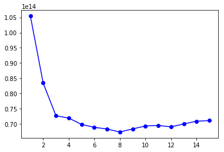

```python
import matplotlib.pyplot as plt
%matplotlib inline

#kvals = range(1, 16)
plt.plot(kvals, rss_all,'bo-')
```

```python
print('The lowest RSS value on VALIDATION set: {:.4}'.format(min(rss_all)))
```

```
The lowest RSS value on VALIDATION set: 6.736e+13
```

*QUIZ QUESTION*

What is the RSS on the TEST data using the value of k found above? To be clear, sum over all houses in the TEST set.

```python
predictions_test_all = predict_multiple_KNN(k_opt, features_train,
                                            output_train,
                                            features_test)
rss_test = np.dot(predictions_test_all - output_test, predictions_test_all - output_test)
print('The RSS on the TEST data using the value of k found above: {:.4}'.format(rss_test))
```

```
The RSS on the TEST data using the value of k found above: 1.331e+14
```

```python
rss_all_test = np.empty(15)
kvals = range(1,16)
for k in kvals:
    #compute len(features_valid) of predictions = num of houses in valid set
    predictions = predict_multiple_KNN(k, features_train,
                                       output_train,
                                       features_test)
    #compute RSS for each given k from 1, 2, ..., 15
    #index of rss_all = k - 1 as python starts with 0
    rss_all_test[k-1] = np.dot(predictions - output_test, predictions - output_test)
k_opt_test = rss_all_test.argmin() + 1
```

[output not shown]

```python
print('The value of k with lowest RSS on TEST set: ', k_opt_test)
print('The lowest RSS value on TEST set: {:.4}'.format((rss_all_test[k_opt_test - 1])))
```

```
The value of k with lowest RSS on TEST set:  7
The lowest RSS value on TEST set: 1.318e+14
```

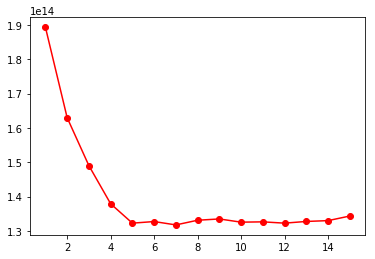

```python
plt.plot(kvals, rss_all_test,'ro-')
```